# ISLR Notes and Exercises

## KNN Classifier

KNN is a completely non-parametric approach: no assumptions are made about the shape of the decision boundary. Therefore, we can expect this approach to dominate LDA and logistic regression when the decision boundary is highly non-linear. On the other hand, KNN does not tell us which predictors are important; we don’t get a table of coefficients.

QDA serves as a compromise between the non-parametric KNN method and the linear LDA and logistic regression approaches. Since QDA assumes a quadratic decision boundary, it can accurately model a wider range of problems than can the linear methods. Though not as flexible as KNN, QDA can perform better in the presence of a limited number of training observations because it does make some assumptions about the form of the decision boundary.

```r
# K-Nearest Neighbors
require(ISLR)
library(class)
attach(Smarket)
```

```r
train=Year<2005 # Indicater Variable
Xlag=cbind(Lag1,Lag2)
dim(Xlag)
```

```
## [1] 1250    2
```

```r
dim(Xlag[train,])
```

```
## [1] 998   2
```

```r
dim(Xlag[!train,])
```

```
## [1] 252   2
```

```r
knn.pred=knn(Xlag[train,],Xlag[!train,],Direction[train],k=1)
summary(knn.pred)
```

```
## Down   Up
##  101  151
```

`knn` function require 4 Inputs:

1. A matrix containing the predictors associated with the training data
2. A matrix containing the predictors associated with the data for which we wish to make predictions
3. A vector containing the class labels for the training observations,
4. A value for K, the number of nearest neighbors to be used by the classifier.

```r
table(knn.pred,Direction[!train])
```

```
##
## knn.pred Down Up
##     Down   43 58
##     Up     68 83
```

```r
mean(knn.pred==Direction[!train])
```

```
## [1] 0.5
```

```r
# Alternatively
train.X=cbind(Lag1,Lag2)[train,]
test.X=cbind(Lag1,Lag2)[!train,]
train.Direction=Direction[train]
set.seed(1)
knn.pred=knn(train.X,test.X,train.Direction,k=1)
table(knn.pred,Direction.2005)
```

```
##         Direction.2005
## knn.pred Down Up
##     Down   43 58
##     Up     68 83
```

```r
(83+43)/252
```

```
## [1] 0.5
```

```r
knn.pred=knn(train.X,test.X,train.Direction,k=3)
table(knn.pred,Direction.2005)
```

```
##         Direction.2005
## knn.pred Down Up
##     Down   48 54
##     Up     63 87
```

```r
mean(knn.pred==Direction.2005)
```

```
## [1] 0.5357143
```

```r
# It appears that for this data, QDA provides the best results
# of the methods that we have examined so far.
```

## Exercises

### Question 4

: When the number of features $p$ is large, there tends to be a deterioration in the performance of KNN and other local approaches that perform prediction using only observations that are near the test observation for which a prediction must be made. This phenomenon is known as the curse of dimensionality and it ties into the fact that parametric approaches often perform poorly when p is large.

Suppose that we have a set of observations, each with measurements on $p = 1$ feature, $X$. We assume that $X$ is uniformly (evenly) distributed on [0, 1]. Associated with each observation is a response value. Suppose that we wish to predict a test observation’s response using only observations that are within $10\%$ of the range of $X$ closest to that test observation. For instance, in order to predict the response for a test observation with $X = 0.6$, we will use observations in the range $[0.55, 0.65]$.On average, what fraction of the available observations will we use to make the prediction?

ANS: $ 0.65-0.55/1=10%$

Now suppose that we have a set of observations, each with measurements on $p = 2$ features, $X_1$ and $X_2$. We assume that $(X_1,X_2)$ are uniformly distributed on $[0, 1] \times [0, 1]$. We wish to predict a test observation’s response using only observations that are within $10\%$ of the range of $X_1$ and within $10\%$ of the range of $X_2$ closest to that test observation. For instance, in order to predict the response for a test observation with $X_1 = 0.6$ and $X_2 = 0.35$, we will use observations in the range $[0.55, 0.65]$ for $X_1$ and in the range $[0.3, 0.4]$ for $X_2$. On average, what fraction of the available observations will we use to make the prediction?

ANS: For 2 features, $(0.65-0.55) * (0.4-0.3) = 1\%$

ANS: For 100 features, we will use $0.10^{100}$ of the available observations.

Consequencly, one drawback of KNN when p is large is that there are very few training observations “near” any given test observation. As the number of predictor, $p$, increases linearly, the percentage of observations that can be used to predict with KNN declines expoentially. This means that for a set sample size, more features leads to fewer neighbors.

A hypercube is a generalization of a cube to an arbitrary number of dimensions. When $p = 1$, a hypercube is simply a line segment, when $p = 2$ it is a square, and when $p = 100$ it is a 100-dimensional cube. Now suppose that we wish to make a prediction for a test observation by creating a p-dimensional hypercube centered around the test observation that contains, on average, $10\%$ of the training observations. For $p$ = 1, 2, and 100, what is the length of each side of the hypercube?

The length of each side of the hypercube increases as $p$ rises. When

- $p = 1, \text{side length} = 0.10$
- $p = 2, \text{side length} = 0.10^{1/2} \approx 0.32$
- $p = 3, \text{side length} = 0.10^{1/3} \approx 0.46$ $...$
- $p = 100, \text{side length} = 0.10^{1/100} \approx 0.98$
- $p = N, \text{side length} = 0.10^{1/N}$

Thus when the number of features is high, to use on average $10\%$ of the training observations would mean that length of the side will asymptotically approach 1. We would need to include almost the entire range of each individual feature.

### Question 5

We now examine the differences between LDA and QDA.

1. If the Bayes decision boundary is linear, do we expect LDA or QDA to perform better on the training set? On the test set?

If the Bayes decision boundary is linear, on the training set, QDA might outperform LDA as it implies a more flexible classifer, thereby entailing a better fit to observations in the training set. On the test set, however, QDA is expected to perform worse than LDA as QDA’s estimators is more sensitive to a change in sample. In other words, QDA overfitting would yield a higher variance of estimators and thus higher expected test MSE. Recall that $E(y_0-\hat{f}(x_0))^2 = Var(\hat{f}(x_0) + [Bias(\hat{f}(x_0))]^2 + Var(\varepsilon)$.

2. If the Bayes decision boundary is non-linear, do we expect LDA or QDA to perform better on the training set? On the test set?

If the Bayes decision boundary is non-linear, on the training set, QDA is expected to outperform LDA as it exerts an extra parameter. Same in the test set given non-lnearity is the correct specified model.

3. In general, as the sample size n increases, do we expect the test prediction accuracy of QDA relative to LDA to improve, decline, or be unchanged? Why?

As the sample size n increases, we expect the test prediction accuracy of QDA relative to LDA to improve. This is because variance of estimators, (which is captured in the overfitting problem) will decline as degrees of freedom increase, holding a given number of estimators.

4. True or False: Even if the Bayes decision boundary for a given problem is linear, we will probably achieve a superior test error rate using QDA rather than LDA because QDA is flexible enough to model a linear decision boundary. Justify your answer

False: The reason is outlined in part(a).

### Question 6

Suppose we collect data for a group of students in a statistics class with variables $X1 =$ hours studied, $X2$ = undergrad GPA, and $Y =$ receive an A. We fit a logistic regression and produce estimated coefficient, $\hat{\beta_0} = -6$, $\hat{\beta_1} = 0.05$, $\hat{\beta_2} = 1$.

1. Estimate the probability that a student who studies for 40 hours and has an undergrad GPA of 3.5 gets an A in the class.

$\text{Pr(required)} = \frac{\exp(-6 + 0.05 \times 40 + 3.5)}{1 + \exp(-6 + 0.05 \times40 + 3.5)}= 0.3775$

2. How many hours would the student in part (a) need to study to have a $50\%$ chance of getting an A in the class?

$0.5 = \frac{\exp(-6 + 0.05 \times x_1 + 3.5)}{1 + \exp(-6 + 0.05 \times x_1 + 3.5)} \Rightarrow x_1 = 50$ hours

### Question 7

Suppose that we wish to predict whether a given stock will issue a dividend this year (“Yes” or “No”) based on $X$, last year’s percent profit.We examine a large number of companies and discover that the mean value of $X$ for companies that issued a dividend was $X = 10$, while the mean for those that didn’t was $X = 0$. In addition, the variance of $X$ for these two sets of companies was $\hat{\sigma}^2 = 36$. Finally, $80\%$ of companies issued dividends. Assuming that $X$ follows a normal distribution, predict the probability that a company will issue a dividend this year given that its percentage profit was $X = 4$ last year.

Using the normal density function and Bayes Therom, $Pr(X=4) = \frac {0.8 \exp(- \frac {1} {2 \times 36} (4 - 10)^2)} {0.8 \exp(- \frac {1} {2 \times 36} (4 - 10)^2) + (1-0.8) \exp(- \frac {1} {2 \times 36} (4 - 0)^2)}$

Note that the $\frac{1}{2\pi\sigma^2}$ parts in the nominator and the denominator cancel out. The denominator comes from the infomation that the decision of paying dividend is bernoulli distributied. The required probibility is 0.75.

### Question 8

Suppose that we take a data set, divide it into equally-sized training and test sets, and then try out two different classification procedures. First we use logistic regression and get an error rate of $20\%$ on the training data and $30\%$ on the test data. Next we use 1-nearest neighbors (i.e. K = 1) and get an average error rate (averaged over both test and training data sets) of $18\%$. Based on these results, which method should we prefer to use for classification of new observations? Why?

Logistic regression should be prefered. That average error rate for 1-nearest neighbors (1NN) is $18\%$ does not imply that training error rate $=$ test error rate $ = 18%$. Moe likely, the training error rate is going to be very low as 1NN is flexible enough to take almost all of the data points into account. This means that it is likely to overfit data in the test set and therefore the test error rate is going to be high (close to $36\%$ in this case). Given that the test error rate for logistic regression is $30\%$, it seems that logistic regression may actually have a lower test error rate.

### Question 9

This problem has to do with odds, $p(X)/[1-p(X)]$. Recall on average nine out of every ten people with an odds of 9 will default, since $p(X) = 0.9$ implies an odds of $0.9/(1-0.9) = 9$ meaning that outcome of $X$ occuring is 9 times more as likely as $X$ not occuring.

1. On average, what fraction of people with an odds of 0.37 of defaulting on their credit card payment will in fact default?

$\frac{p}{1-p} = 0.37 \Rightarrow p = 0.27$

2. Suppose that an individual has a $16\%$ chance of defaulting on her credit card payment. What are the odds that she will default?

$\frac{0.16}{1-0.16} = 0.19$

### Question 10

This applied question works on the `Weekly` dataset which consist of weekly percentage returns for the S&P 500 stock index between 1990 and 2010. Except for `Year` and `Volume`, variables seem to be uncorrelated with one another.

```r
library(ISLR)
dim(Weekly)
```

```
## [1] 1089    9
```

```r
summary(Weekly)
```

```
##       Year           Lag1               Lag2               Lag3
##  Min.   :1990   Min.   :-18.1950   Min.   :-18.1950   Min.   :-18.1950
##  1st Qu.:1995   1st Qu.: -1.1540   1st Qu.: -1.1540   1st Qu.: -1.1580
##  Median :2000   Median :  0.2410   Median :  0.2410   Median :  0.2410
##  Mean   :2000   Mean   :  0.1506   Mean   :  0.1511   Mean   :  0.1472
##  3rd Qu.:2005   3rd Qu.:  1.4050   3rd Qu.:  1.4090   3rd Qu.:  1.4090
##  Max.   :2010   Max.   : 12.0260   Max.   : 12.0260   Max.   : 12.0260
##       Lag4               Lag5              Volume
##  Min.   :-18.1950   Min.   :-18.1950   Min.   :0.08747
##  1st Qu.: -1.1580   1st Qu.: -1.1660   1st Qu.:0.33202
##  Median :  0.2380   Median :  0.2340   Median :1.00268
##  Mean   :  0.1458   Mean   :  0.1399   Mean   :1.57462
##  3rd Qu.:  1.4090   3rd Qu.:  1.4050   3rd Qu.:2.05373
##  Max.   : 12.0260   Max.   : 12.0260   Max.   :9.32821
##      Today          Direction
##  Min.   :-18.1950   Down:484
##  1st Qu.: -1.1540   Up  :605
##  Median :  0.2410
##  Mean   :  0.1499
##  3rd Qu.:  1.4050
##  Max.   : 12.0260
```

```r
cor(Weekly[,2:8])
```

```
##                Lag1        Lag2        Lag3         Lag4         Lag5
## Lag1    1.000000000 -0.07485305  0.05863568 -0.071273876 -0.008183096
## Lag2   -0.074853051  1.00000000 -0.07572091  0.058381535 -0.072499482
## Lag3    0.058635682 -0.07572091  1.00000000 -0.075395865  0.060657175
## Lag4   -0.071273876  0.05838153 -0.07539587  1.000000000 -0.075675027
## Lag5   -0.008183096 -0.07249948  0.06065717 -0.075675027  1.000000000
## Volume -0.064951313 -0.08551314 -0.06928771 -0.061074617 -0.058517414
## Today  -0.075031842  0.05916672 -0.07124364 -0.007825873  0.011012698
##             Volume        Today
## Lag1   -0.06495131 -0.075031842
## Lag2   -0.08551314  0.059166717
## Lag3   -0.06928771 -0.071243639
## Lag4   -0.06107462 -0.007825873
## Lag5   -0.05851741  0.011012698
## Volume  1.00000000 -0.033077783
## Today  -0.03307778  1.000000000
```

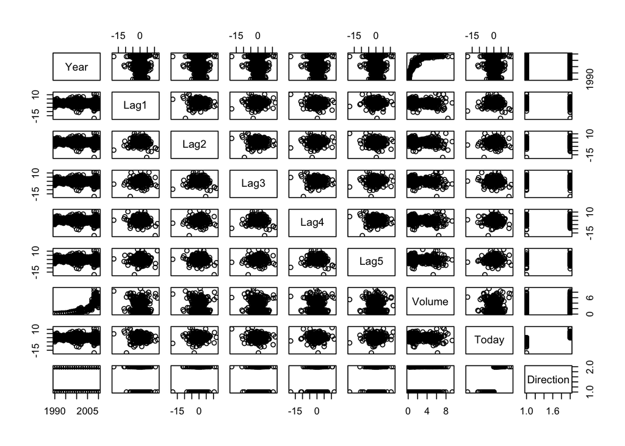

```r
pairs(Weekly)
```

```r
# Logistic Regression (Full Model)
glm.fit=glm(Direction~Lag1+Lag2+Lag3+Lag4+Lag5+Volume,
data=Weekly,family=binomial(link = "logit"))
summary(glm.fit)
```

```
##
## Call:
## glm(formula = Direction ~ Lag1 + Lag2 + Lag3 + Lag4 + Lag5 +
##     Volume, family = binomial(link = "logit"), data = Weekly)
##
## Deviance Residuals:
##     Min       1Q   Median       3Q      Max
## -1.6949  -1.2565   0.9913   1.0849   1.4579
##
## Coefficients:
##             Estimate Std. Error z value Pr(>|z|)
## (Intercept)  0.26686    0.08593   3.106   0.0019 **
## Lag1        -0.04127    0.02641  -1.563   0.1181
## Lag2         0.05844    0.02686   2.175   0.0296 *
## Lag3        -0.01606    0.02666  -0.602   0.5469
## Lag4        -0.02779    0.02646  -1.050   0.2937
## Lag5        -0.01447    0.02638  -0.549   0.5833
## Volume      -0.02274    0.03690  -0.616   0.5377
## ---
## Signif. codes:  0 '***' 0.001 '**' 0.01 '*' 0.05 '.' 0.1 ' ' 1
##
## (Dispersion parameter for binomial family taken to be 1)
##
##     Null deviance: 1496.2  on 1088  degrees of freedom
## Residual deviance: 1486.4  on 1082  degrees of freedom
## AIC: 1500.4
##
## Number of Fisher Scoring iterations: 4
```

```r
glm.probs=predict(glm.fit,type="response")
glm.probs[2:8]
```

```
##         2         3         4         5         6         7         8
## 0.6010314 0.5875699 0.4816416 0.6169013 0.5684190 0.5786097 0.5151972
```

```r
contrasts(Weekly$Direction) #See how R code the dummy response vaiable
```

```
##      Up
## Down  0
## Up    1
```

```r
# Odd Ratios
exp(glm.fit$coefficients)
```

```
## (Intercept)        Lag1        Lag2        Lag3        Lag4        Lag5
##   1.3058630   0.9595710   1.0601831   0.9840671   0.9725924   0.9856322
##      Volume
##   0.9775151
```

```r
# Marginal Effect
(pdf <-  mean(dlogis(predict(glm.fit, type = "link"))))
```

```
## [1] 0.2447041
```

```r
(marginal.effects <- pdf*coef(glm.fit))
```

```
##  (Intercept)         Lag1         Lag2         Lag3         Lag4
##  0.065302739 -0.010098677  0.014300915 -0.003930227 -0.006800377
##         Lag5       Volume
## -0.003541373 -0.005564945
```

The type=“response” option tells R to output probabilities of the form $P(Y = 1|X)$, as opposed to other information such as the logit. From the result, only the coefficient of `Lag2` is statistically significant with a p-value of 0.0296.

One way to interpret the significant coefficient of `Lag2` is that holding other variables constant, an extra one percentage return for 2 weeks previous increases the probability of positive return of hte market on a given week by $1.43\%$.

```r
# Confusion Matrix
glm.pred=rep("Down", length(glm.probs))
glm.pred[glm.probs >.5] = "Up"
(t<-table(glm.pred, Weekly$Direction))
```

```
##
## glm.pred Down  Up
##     Down   54  48
##     Up    430 557
```

```r
sum(diag(t))/sum(t) # True Positive Rate
```

```
## [1] 0.5610652
```

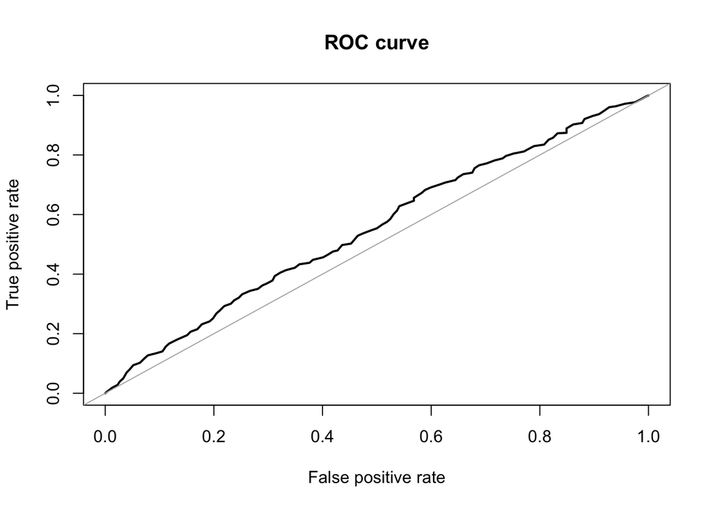

```
## Area under the curve (AUC): 0.554
```

```r
# ROC Curve
library(rpart);library(ROSE)
Dec_Tree<-rpart(Direction~Lag1+Lag2+Lag3+Lag4+Lag5+Volume,data=Weekly)
roc.curve(Weekly$Direction, glm.probs)
```

```r
plot(Dec_Tree) #text(Dec_Tree, pretty=0) #summary(Dec_Tree)
exp(coef(glm.fit)) # exponentiated coefficients
exp(confint(glm.fit)) # 95% CI for exponentiated coefficients
```

[output not shown]

- False Positive Rate (FP/N) $= (48+430)/1089 = 43.89\%$ = .
- True Positive Rate (TP/N) $= (54+557)/1089 = 56.1\%$
- When `Direction` is `Up`, logit correctly predicts that $557/(557+48) = 92.06\%$ of the time.
- When `Direction` is `Down`, logit correctly predicts that $54/(54+430) = 11.15\%$ of the time.

It seems that logit model has a high accuracy in detecting market return rising but does a poor job in identifying market return falling. Overall, the model perform fairly as the Area under the curve (AUC) is merely 0.554, slightly higher than 0.5. But this is expected for any typical stock market data.

```r
library(pROC)
auc(Weekly$Direction ~ glm.probs)
plot(roc(Weekly$Direction, glm.probs), main="ROC curve")
```

Moving on to applying logistic regression model on a training data period from 1990 to 2008 with `Lag2` as the only predictor, we can see noticeable improvement in accuracy which has risen to $62.5\%$. Yet, AUC, the percentage of the ROC plot that is underneath the curve, is $0.546$, slightly less than that of the full model ($0.554$). These may reflect class imbalance (only 14 cases of `Down` but 90 for `Up`. Under this circumstance, AUC is more reliable as it is immune to class imbalance.

Another advantage is that AUC does not require a classification threshold. Yet, AUC is not ideal as it uses different misclassification cost distributions for different classifiers. This means that using the AUC is equivalent to using different metrics to evaluate different classification rules. For further information, see https://www.r-bloggers.com/illustrated-guide-to-roc-and-auc/

```r
# Applying Logit Model from train set 1990-2008 to test set 2009-2010
train.yrs <- Weekly$Year %in% (1990:2008)
  #this subsetting method is different from the book
train <- Weekly[train.yrs,]
test <- Weekly[!train.yrs,]
glm.fit2 <- glm(Direction~Lag2, data=train, family=binomial)
summary(glm.fit2)
```

```
##
## Call:
## glm(formula = Direction ~ Lag2, family = binomial, data = train)
##
## Deviance Residuals:
##    Min      1Q  Median      3Q     Max
## -1.536  -1.264   1.021   1.091   1.368
##
## Coefficients:
##             Estimate Std. Error z value Pr(>|z|)
## (Intercept)  0.20326    0.06428   3.162  0.00157 **
## Lag2         0.05810    0.02870   2.024  0.04298 *
## ---
## Signif. codes:  0 '***' 0.001 '**' 0.01 '*' 0.05 '.' 0.1 ' ' 1
##
## (Dispersion parameter for binomial family taken to be 1)
##
##     Null deviance: 1354.7  on 984  degrees of freedom
## Residual deviance: 1350.5  on 983  degrees of freedom
## AIC: 1354.5
##
## Number of Fisher Scoring iterations: 4
```

```r
glm.prob2 <- predict(glm.fit2, test, type="response")
summary(glm.prob2)
```

```
##    Min. 1st Qu.  Median    Mean 3rd Qu.    Max.
##  0.4488  0.5331  0.5573  0.5555  0.5826  0.6954
```

```r
glm.pred2 <- ifelse(glm.prob2 > 0.5, "Up", "Down")
table(glm.pred2, test$Direction)
```

```
##
## glm.pred2 Down Up
##      Down    9  5
##      Up     34 56
```

```r
mean(glm.pred2 == test$Direction)   # Accuracy=0.625
```

```
## [1] 0.625
```

```r
(pdf2 <-  mean(dlogis(predict(glm.fit2, type = "link"))))
```

```
## [1] 0.2462242
```

```r
(marginal.effect2 <- pdf2*coef(glm.fit2)) # same magnitude as before
```

```
## (Intercept)        Lag2
##  0.05004689  0.01430446
```

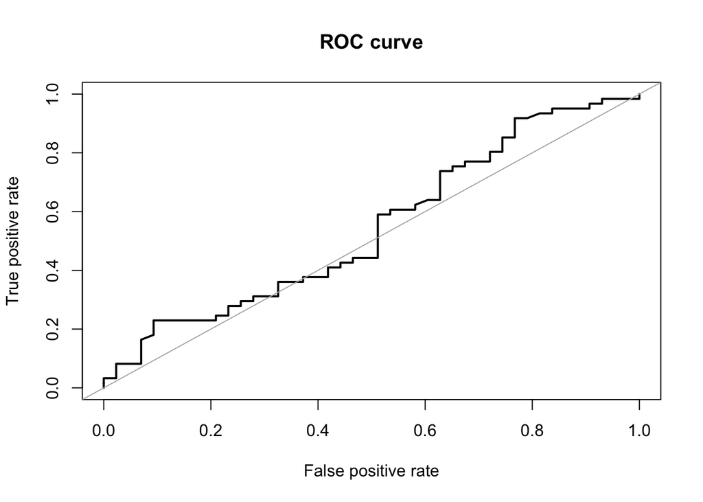

```
## Area under the curve (AUC): 0.546
```

```r
# ROC from model on test set
library(rpart); library(ROSE)
Dec_Tree<-rpart(test$Direction~Lag2,data=test)
roc.curve(test$Direction, glm.prob2)
```

```r
# Strangly pROC package gives AUC less than 0.5...
library(pROC)
(auc_2 <- auc(test$Direction ~ glm.prob2))
plot(roc(test$Direction, glm.prob2), main="ROC curve")
```

```r
# Linear Discriminant Analysis
library(MASS)
(lda.fit = lda(train$Direction~Lag2, data=train))
```

```
## Call:
## lda(train$Direction ~ Lag2, data = train)
##
## Prior probabilities of groups:
##      Down        Up
## 0.4477157 0.5522843
##
## Group means:
##             Lag2
## Down -0.03568254
## Up    0.26036581
##
## Coefficients of linear discriminants:
##            LD1
## Lag2 0.4414162
```

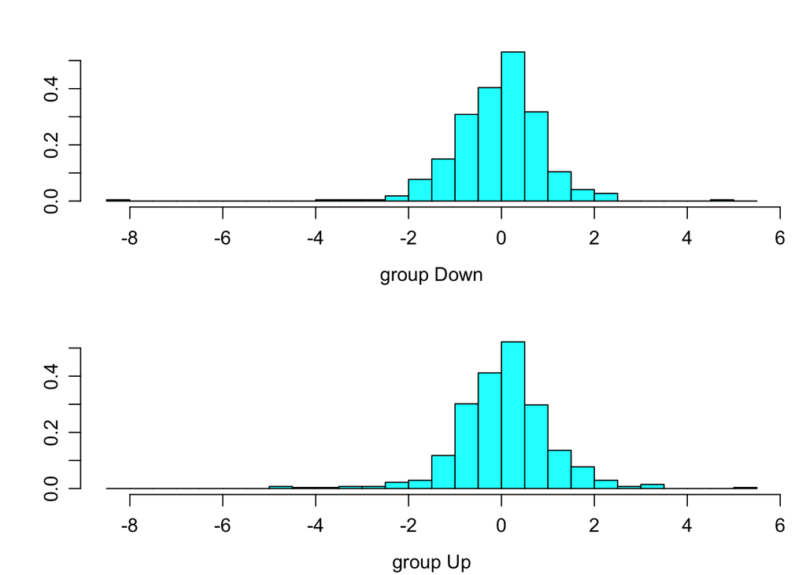

```r
#pi hat for class 1&2
#Group mean for Lag2 Up = mean(test$Lag2[test$Direction=='Up'])
par(mar=c(3.5, 3.5, 2, 1), mgp=c(2.4, 0.8, 0)); plot(lda.fit)
```

```r
#plot() produces plots of the linear discriminants: LD coefficient*Lag2.
#hist(0.3262636*test$Lag2[test$Direction=='Down'], breaks = 50)
#hist(0.3262636*test$Lag2[test$Direction=='Up'], breaks = 50)
lda.pred <- predict(lda.fit, test); names(lda.pred)
```

```
## [1] "class"     "posterior" "x"
```

```r
table(lda.pred$class, test$Direction)
```

```
##
##        Down Up
##   Down    9  5
##   Up     34 56
```

```r
mean(lda.pred$class == test$Direction)  # Accuracy = 0.625
```

```
## [1] 0.625
```

```r
sum(lda.pred$posterior[,1]>=.5)
```

```
## [1] 14
```

```r
#count of obs over posterior prob threshold of 0.5
#Threshold can be adjusted to increase sensitivity or specificity
sum(lda.pred$posterior[,1]<.5) # sum of row 2 of the confusion matrix
```

```
## [1] 90
```

“Accuracy is not a reliable metric for the real performance of a classifier, because it yields misleading results when the numbers of observations in different classes vary greatly.” (Wiki).

```r
# Quadratic Discriminant Analysis
(qda.fit<-qda(Direction~Lag2,data=train))
```

```
## Call:
## qda(Direction ~ Lag2, data = train)
##
## Prior probabilities of groups:
##      Down        Up
## 0.4477157 0.5522843
##
## Group means:
##             Lag2
## Down -0.03568254
## Up    0.26036581
```

```r
qda.pred<-predict(qda.fit, test)
table(qda.pred$class, test$Direction)
```

```
##
##        Down Up
##   Down    0  0
##   Up     43 61
```

```r
mean(qda.pred$class == test$Direction) # Accuracy = 0.5865
```

```
## [1] 0.5865385
```

One noticeable result from QDA is that it scores an accuracy of $58.7\%$ even though it only chooses `Up` the whole time. Not surprisingly, the prior probabilities of groups and group means are the same as in LDA (they are the inputs of the model!).

```r
# KNN with K = 1: 2 matrix, 1 vector, 1 scaler as inputs
library(class); set.seed(1);
train.Lag2 = as.matrix(train$Lag2); test.Lag2 = as.matrix(test$Lag2);
knn.pred = knn(train.Lag2, test.Lag2, train$Direction, k=1)
table(knn.pred, test$Direction)
```

```
##
## knn.pred Down Up
##     Down   21 30
##     Up     22 31
```

```r
mean(knn.pred == test$Direction)
```

```
## [1] 0.5
```

Next shows that the results using KNN with $K=1$ on `Direction` and `Lag2` are not very good, since only $50\%$ of the observations are correctly predicted. This is probably because $K = 1$ results in an overly flexible fit to the data. Increasing the number of nearest neighbor results in higher accuracy. $K=4$ seems to be a reasonable choice at least locally. See below:

```r
# Accuracy as a result of increase of K
set.seed(1); knn_acc <- c()
for (i in c(1:10)){
knn.pred = knn(train.Lag2, test.Lag2, train$Direction, k=i)
m <-mean(knn.pred == test$Direction)
knn_acc <- c(knn_acc, m)}
names(knn_acc)<-(1:length(knn_acc))
knn_acc; max(knn_acc);
```

```
##         1         2         3         4         5         6         7
## 0.5000000 0.5192308 0.5480769 0.5961538 0.5192308 0.5384615 0.5384615
##         8         9        10
## 0.5384615 0.5480769 0.5769231
```

```
## [1] 0.5961538
```

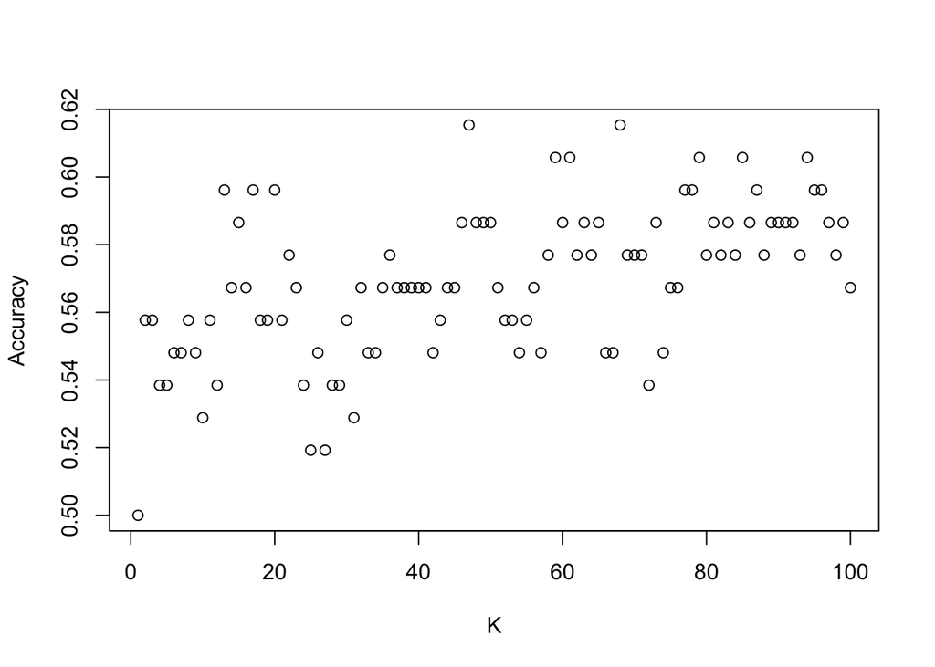

```r
# More on accuracy as a result of increase of K
knn_acc <- c()
for (i in c(1:100)){
knn.pred = knn(train.Lag2, test.Lag2, train$Direction, k=i)
m <-mean(knn.pred == test$Direction)
knn_acc <- c(knn_acc, m)}
plot(knn_acc, xlab="K", ylab="Accuracy")
```

```r
library(ggplot2); knn_acc<-data.frame(knn_acc);
ggplot(data = knn_acc) +
  geom_point(mapping = aes(x = c(1:length(knn_acc)), y = knn_acc)) +
  xlab("K") + ylab("Accuracy")
```

Based on the work presented so far, logistic regression and LDA ($p=1$) provide similar and better test error rates and accuracy than QDA and KNN ($K=1$).

### Question 11